# Indian Personal Finance and Spending Habits Project

#### **Brief Description of the Project:** Developed and evaluated predictive regression models using deep learning Neural Networks, Machine Learning bagging and boosting algorithms like Random Forest and XGBoost on a large financial dataset. Applied data preprocessing, feature engineering and model tuning. Utilized performance metrics (MSE, MAE, R²) and visualizations for model comparison. Demonstrated skills in Python, machine learning, data analysis, data science, model evaluation and visualization using libraries such as numpy, pandas, matplotlib, seaborn, scikit-learn, TensorFlow etc.

### Importing necessary libraries

```python
import numpy as np
import pandas as pd
import matplotlib.pyplot as plt
from matplotlib.ticker import ScalarFormatter, MaxNLocator
import seaborn as sns

from sklearn.model_selection import train_test_split
from sklearn.preprocessing import LabelEncoder, StandardScaler
from sklearn.ensemble import RandomForestRegressor
from xgboost.sklearn import XGBRegressor
import xgboost as xgb
from sklearn.metrics import mean_squared_error, mean_absolute_error, r2_score

from tensorflow.keras.models import Sequential
from tensorflow.keras.layers import Dense
from tensorflow.keras.models import Model
from tensorflow.keras.layers import (
    Dense, Dropout, LayerNormalization, MultiHeadAttention,Layer, GlobalAveragePooling1D, Input,Reshape, Lambda,Attention)
from tensorflow.keras.optimizers import Adam

import warnings
warnings.filterwarnings('ignore')
```

### Loading the dataset

```python
df=pd.read_csv(r"D:\Data Science\Projects\1. Indian Personal Finance and Spending Habits Project\data.csv")
df.head()
```

|  | Income | Age | Dependents | Occupation | City_Tier | Rent | Loan_Repayment | Insurance | Groceries | Transport | ... | Desired_Savings | Disposable_Income | Potential_Savings_Groceries | Potential_Savings_Transport | Potential_Savings_Eating_Out | Potential_Savings_Entertainment | Potential_Savings_Utilities | Potential_Savings_Healthcare | Potential_Savings_Education | Potential_Savings_Miscellaneous |
| --- | --- | --- | --- | --- | --- | --- | --- | --- | --- | --- | --- | --- | --- | --- | --- | --- | --- | --- | --- | --- | --- |
| 0 | 44637.249636 | 49 | 0 | Self_Employed | Tier_1 | 13391.174891 | 0.000000 | 2206.490129 | 6658.768341 | 2636.970696 | ... | 6200.537192 | 11265.627707 | 1685.696222 | 328.895281 | 465.769172 | 195.151320 | 678.292859 | 67.682471 | 0.000000 | 85.735517 |
| 1 | 26858.596592 | 34 | 2 | Retired | Tier_2 | 5371.719318 | 0.000000 | 869.522617 | 2818.444460 | 1543.018778 | ... | 1923.176434 | 9676.818733 | 540.306561 | 119.347139 | 141.866089 | 234.131168 | 286.668408 | 6.603212 | 56.306874 | 97.388606 |
| 2 | 50367.605084 | 35 | 1 | Student | Tier_3 | 7555.140763 | 4612.103386 | 2201.800050 | 6313.222081 | 3221.396403 | ... | 7050.360422 | 13891.450624 | 1466.073984 | 473.549752 | 410.857129 | 459.965256 | 488.383423 | 7.290892 | 106.653597 | 138.542422 |
| 3 | 101455.600247 | 21 | 0 | Self_Employed | Tier_3 | 15218.340037 | 6809.441427 | 4889.418087 | 14690.149363 | 7106.130005 | ... | 16694.965136 | 31617.953615 | 1875.932770 | 762.020789 | 1241.017448 | 320.190594 | 1389.815033 | 193.502754 | 0.000000 | 296.041183 |
| 4 | 24875.283548 | 52 | 4 | Professional | Tier_2 | 4975.056710 | 3112.609398 | 635.907170 | 3034.329665 | 1276.155163 | ... | 1874.099434 | 6265.700532 | 788.953124 | 68.160766 | 61.712505 | 187.173750 | 194.117130 | 47.294591 | 67.388120 | 96.557076 |

5 rows × 27 columns

### About Dataset

The dataset used contains detailed financial and demographic data for 20,000 individuals, focusing on income, expenses, and potential savings across various categories. The data aims to provide insights into personal financial management and spending patterns using the following:

**Income**: Monthly income in currency units (INR).  
**Age**: Age of the individual.  
**Dependents**: Number of dependents supported by the individual.  
**Occupation**: Type of employment or job role.  
**City_Tier**: A categorical variable representing the living area tier (e.g., Tier 1, Tier 2).  
**Monthly Expenses**: Categories like Rent, Loan_Repayment, Insurance, Groceries, Transport, Eating_Out, Entertainment, Utilities, Healthcare, Education, and Miscellaneous record various monthly expenses.  
**Desired_Savings_Percentage and Desired_Savings**: Targets for monthly savings.  
**Disposable_Income**: Income remaining after all expenses are accounted for.  
**Potential Savings**: Includes estimates of potential savings across different spending areas such as Groceries, Transport, Eating_Out, Entertainment, Utilities, Healthcare, Education, and Miscellaneous.

```python
df.round(2)
```

|  | Income | Age | Dependents | Occupation | City_Tier | Rent | Loan_Repayment | Insurance | Groceries | Transport | ... | Desired_Savings | Disposable_Income | Potential_Savings_Groceries | Potential_Savings_Transport | Potential_Savings_Eating_Out | Potential_Savings_Entertainment | Potential_Savings_Utilities | Potential_Savings_Healthcare | Potential_Savings_Education | Potential_Savings_Miscellaneous |
| --- | --- | --- | --- | --- | --- | --- | --- | --- | --- | --- | --- | --- | --- | --- | --- | --- | --- | --- | --- | --- | --- |
| 0 | 44637.25 | 49 | 0 | Self_Employed | Tier_1 | 13391.17 | 0.00 | 2206.49 | 6658.77 | 2636.97 | ... | 6200.54 | 11265.63 | 1685.70 | 328.90 | 465.77 | 195.15 | 678.29 | 67.68 | 0.00 | 85.74 |
| 1 | 26858.60 | 34 | 2 | Retired | Tier_2 | 5371.72 | 0.00 | 869.52 | 2818.44 | 1543.02 | ... | 1923.18 | 9676.82 | 540.31 | 119.35 | 141.87 | 234.13 | 286.67 | 6.60 | 56.31 | 97.39 |
| 2 | 50367.61 | 35 | 1 | Student | Tier_3 | 7555.14 | 4612.10 | 2201.80 | 6313.22 | 3221.40 | ... | 7050.36 | 13891.45 | 1466.07 | 473.55 | 410.86 | 459.97 | 488.38 | 7.29 | 106.65 | 138.54 |
| 3 | 101455.60 | 21 | 0 | Self_Employed | Tier_3 | 15218.34 | 6809.44 | 4889.42 | 14690.15 | 7106.13 | ... | 16694.97 | 31617.95 | 1875.93 | 762.02 | 1241.02 | 320.19 | 1389.82 | 193.50 | 0.00 | 296.04 |
| 4 | 24875.28 | 52 | 4 | Professional | Tier_2 | 4975.06 | 3112.61 | 635.91 | 3034.33 | 1276.16 | ... | 1874.10 | 6265.70 | 788.95 | 68.16 | 61.71 | 187.17 | 194.12 | 47.29 | 67.39 | 96.56 |
| ... | ... | ... | ... | ... | ... | ... | ... | ... | ... | ... | ... | ... | ... | ... | ... | ... | ... | ... | ... | ... | ... |
| 19995 | 40913.47 | 51 | 4 | Self_Employed | Tier_1 | 12274.04 | 7703.85 | 1646.80 | 5477.40 | 2084.23 | ... | 1163.32 | 1163.32 | 597.03 | 287.32 | 347.66 | 145.84 | 212.83 | 44.90 | 98.77 | 190.59 |
| 19996 | 90295.77 | 21 | 1 | Student | Tier_2 | 18059.15 | 0.00 | 2770.59 | 13118.22 | 4633.11 | ... | 10613.59 | 30725.18 | 3854.82 | 359.60 | 911.27 | 424.06 | 1555.55 | 129.66 | 239.45 | 351.44 |
| 19997 | 40604.57 | 30 | 1 | Professional | Tier_2 | 8120.91 | 8089.61 | 1548.56 | 6018.28 | 2493.56 | ... | 2267.91 | 2267.91 | 1385.51 | 379.93 | 138.21 | 297.70 | 824.57 | 57.89 | 72.73 | 122.57 |
| 19998 | 118157.82 | 27 | 2 | Professional | Tier_1 | 35447.35 | 12345.91 | 4735.67 | 16392.44 | 8248.24 | ... | 10603.68 | 10603.68 | 3217.77 | 2265.87 | 726.25 | 273.91 | 859.23 | 98.96 | 92.19 | 569.81 |
| 19999 | 8209.25 | 62 | 3 | Professional | Tier_1 | 2462.77 | 1120.88 | 276.38 | 969.92 | 460.44 | ... | 531.04 | 860.35 | 261.16 | 124.06 | 25.94 | 35.24 | 94.91 | 1.69 | 4.84 | 12.77 |

20000 rows × 27 columns

```python
df.shape
```

```
(20000, 27)
```

```python
df.size
```

```
540000
```

```python
df.info()
```

```
<class 'pandas.core.frame.DataFrame'>
RangeIndex: 20000 entries, 0 to 19999
Data columns (total 27 columns):
 #   Column                           Non-Null Count  Dtype
---  ------                           --------------  -----
 0   Income                           20000 non-null  float64
 1   Age                              20000 non-null  int64
 2   Dependents                       20000 non-null  int64
 3   Occupation                       20000 non-null  object
 4   City_Tier                        20000 non-null  object
 5   Rent                             20000 non-null  float64
 6   Loan_Repayment                   20000 non-null  float64
 7   Insurance                        20000 non-null  float64
 8   Groceries                        20000 non-null  float64
 9   Transport                        20000 non-null  float64
```

[output cut: 19 more lines]

```python
df.describe()
```

|  | Income | Age | Dependents | Rent | Loan_Repayment | Insurance | Groceries | Transport | Eating_Out | Entertainment | ... | Desired_Savings | Disposable_Income | Potential_Savings_Groceries | Potential_Savings_Transport | Potential_Savings_Eating_Out | Potential_Savings_Entertainment | Potential_Savings_Utilities | Potential_Savings_Healthcare | Potential_Savings_Education | Potential_Savings_Miscellaneous |
| --- | --- | --- | --- | --- | --- | --- | --- | --- | --- | --- | --- | --- | --- | --- | --- | --- | --- | --- | --- | --- | --- |
| count | 2.000000e+04 | 20000.000000 | 20000.000000 | 20000.000000 | 20000.000000 | 20000.000000 | 20000.000000 | 20000.000000 | 20000.000000 | 20000.000000 | ... | 20000.000000 | 20000.000000 | 20000.000000 | 20000.000000 | 20000.000000 | 20000.000000 | 20000.000000 | 20000.000000 | 20000.000000 | 20000.000000 |
| mean | 4.158550e+04 | 41.031450 | 1.995950 | 9115.494629 | 2049.800292 | 1455.028761 | 5205.667493 | 2704.466685 | 1461.856982 | 1448.853658 | ... | 4982.878416 | 10647.367257 | 912.197183 | 473.042650 | 254.963280 | 254.031058 | 436.332808 | 41.524964 | 62.417083 | 144.904987 |
| std | 4.001454e+04 | 13.578725 | 1.417616 | 9254.228188 | 4281.789941 | 1492.938435 | 5035.953689 | 2666.345648 | 1481.660811 | 1489.019270 | ... | 7733.468188 | 11740.637289 | 1038.884968 | 537.222853 | 296.047943 | 299.973590 | 503.200658 | 53.152458 | 98.842656 | 169.160951 |
| min | 1.301187e+03 | 18.000000 | 0.000000 | 235.365692 | 0.000000 | 30.002012 | 154.078240 | 81.228584 | 39.437523 | 45.421469 | ... | 0.000000 | -5400.788673 | 16.575501 | 8.268076 | 3.797926 | 3.121610 | 6.200297 | 0.001238 | 0.000000 | 2.091973 |
| 25% | 1.760488e+04 | 29.000000 | 1.000000 | 3649.422246 | 0.000000 | 580.204749 | 2165.426419 | 1124.578012 | 581.011801 | 581.632906 | ... | 1224.932636 | 3774.894323 | 317.811000 | 161.913751 | 84.506870 | 84.562090 | 148.013618 | 11.037421 | 4.926210 | 47.637307 |
| 50% | 3.018538e+04 | 41.000000 | 2.000000 | 6402.751824 | 0.000000 | 1017.124681 | 3741.091535 | 1933.845509 | 1029.109726 | 1020.198376 | ... | 2155.356763 | 7224.890977 | 607.038735 | 307.045856 | 164.927660 | 164.740232 | 285.739582 | 25.202124 | 33.127987 | 93.090257 |
| 75% | 5.176545e+04 | 53.000000 | 3.000000 | 11263.940492 | 2627.142320 | 1787.160895 | 6470.892718 | 3360.597508 | 1807.075251 | 1790.104082 | ... | 6216.309609 | 13331.950716 | 1128.681837 | 588.419602 | 313.398240 | 310.927935 | 538.983703 | 52.353736 | 80.946145 | 178.257981 |
| max | 1.079728e+06 | 64.000000 | 4.000000 | 215945.674703 | 123080.682009 | 38734.932935 | 119816.898124 | 81861.503457 | 34406.100166 | 38667.368308 | ... | 245504.485208 | 377060.218482 | 34894.644404 | 12273.258242 | 5573.036433 | 6222.200913 | 8081.799518 | 1394.531049 | 3647.244243 | 4637.951137 |

8 rows × 25 columns

### Handling missing values

```python
df.isna().sum()
```

```
Income                             0
Age                                0
Dependents                         0
Occupation                         0
City_Tier                          0
Rent                               0
Loan_Repayment                     0
Insurance                          0
Groceries                          0
Transport                          0
Eating_Out                         0
Entertainment                      0
Utilities                          0
Healthcare                         0
Education                          0
Miscellaneous                      0
Desired_Savings_Percentage         0
Desired_Savings                    0
Disposable_Income                  0
Potential_Savings_Groceries        0
Potential_Savings_Transport        0
Potential_Savings_Eating_Out       0
Potential_Savings_Entertainment    0
Potential_Savings_Utilities        0
Potential_Savings_Healthcare       0
Potential_Savings_Education        0
Potential_Savings_Miscellaneous    0
dtype: int64
```

### Handling duplicate values

```python
df.duplicated().any()
```

```
False
```

### EDA with visualizations

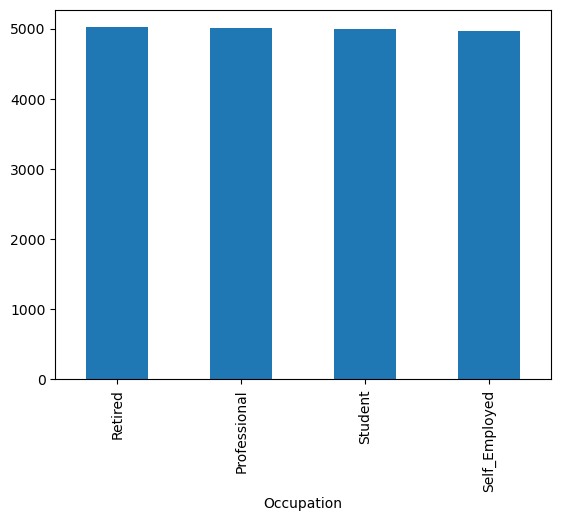

```python
df['Occupation'].value_counts().plot(kind='bar')
```

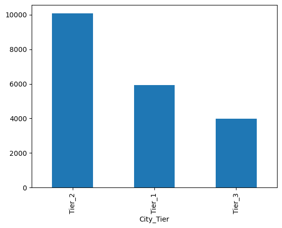

```python
df['City_Tier'].value_counts().plot(kind='bar')
```

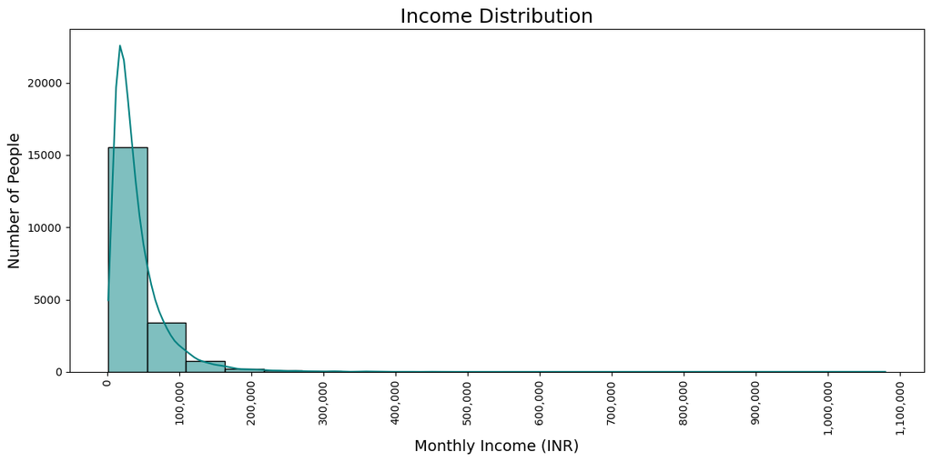

```python
plt.figure(figsize=(12, 6))
sns.histplot(df['Income'], bins=20, kde=True, color='teal')

ax = plt.gca()
ax.xaxis.set_major_formatter(ScalarFormatter())  # Disable scientific notation
ax.ticklabel_format(style='plain', axis='x')
ax.xaxis.set_major_locator(MaxNLocator(nbins=12))  # Increase number of x-ticks

# Rotate x-axis labels vertically and round them
xticks = ax.get_xticks()
ax.set_xticklabels([f"{int(x):,}" for x in xticks], rotation=90)

plt.title('Income Distribution', fontsize=18)
plt.xlabel('Monthly Income (INR)', fontsize=14)
plt.ylabel('Number of People', fontsize=14)
plt.tight_layout()
plt.show()
```

```python
# Change type of categorical features with numerical ones
le = LabelEncoder()

df['Occupation'] = le.fit_transform(df['Occupation'])
print("Occupation mapping:", dict(zip(le.classes_, le.transform(le.classes_))))

df['City_Tier'] = le.fit_transform(df['City_Tier'])
print("City_Tier mapping:", dict(zip(le.classes_, le.transform(le.classes_))))

df.head()
```

```
Occupation mapping: {'Professional': 0, 'Retired': 1, 'Self_Employed': 2, 'Student': 3}
City_Tier mapping: {'Tier_1': 0, 'Tier_2': 1, 'Tier_3': 2}
```

|  | Income | Age | Dependents | Occupation | City_Tier | Rent | Loan_Repayment | Insurance | Groceries | Transport | ... | Desired_Savings | Disposable_Income | Potential_Savings_Groceries | Potential_Savings_Transport | Potential_Savings_Eating_Out | Potential_Savings_Entertainment | Potential_Savings_Utilities | Potential_Savings_Healthcare | Potential_Savings_Education | Potential_Savings_Miscellaneous |
| --- | --- | --- | --- | --- | --- | --- | --- | --- | --- | --- | --- | --- | --- | --- | --- | --- | --- | --- | --- | --- | --- |
| 0 | 44637.249636 | 49 | 0 | 2 | 0 | 13391.174891 | 0.000000 | 2206.490129 | 6658.768341 | 2636.970696 | ... | 6200.537192 | 11265.627707 | 1685.696222 | 328.895281 | 465.769172 | 195.151320 | 678.292859 | 67.682471 | 0.000000 | 85.735517 |
| 1 | 26858.596592 | 34 | 2 | 1 | 1 | 5371.719318 | 0.000000 | 869.522617 | 2818.444460 | 1543.018778 | ... | 1923.176434 | 9676.818733 | 540.306561 | 119.347139 | 141.866089 | 234.131168 | 286.668408 | 6.603212 | 56.306874 | 97.388606 |
| 2 | 50367.605084 | 35 | 1 | 3 | 2 | 7555.140763 | 4612.103386 | 2201.800050 | 6313.222081 | 3221.396403 | ... | 7050.360422 | 13891.450624 | 1466.073984 | 473.549752 | 410.857129 | 459.965256 | 488.383423 | 7.290892 | 106.653597 | 138.542422 |
| 3 | 101455.600247 | 21 | 0 | 2 | 2 | 15218.340037 | 6809.441427 | 4889.418087 | 14690.149363 | 7106.130005 | ... | 16694.965136 | 31617.953615 | 1875.932770 | 762.020789 | 1241.017448 | 320.190594 | 1389.815033 | 193.502754 | 0.000000 | 296.041183 |
| 4 | 24875.283548 | 52 | 4 | 0 | 1 | 4975.056710 | 3112.609398 | 635.907170 | 3034.329665 | 1276.155163 | ... | 1874.099434 | 6265.700532 | 788.953124 | 68.160766 | 61.712505 | 187.173750 | 194.117130 | 47.294591 | 67.388120 | 96.557076 |

5 rows × 27 columns

### Expense Analysis

#### 1. Fixed Expenses

Fixed expenses include Rent, Loan Repayment, and Insurance. Let's analyze their distributions.

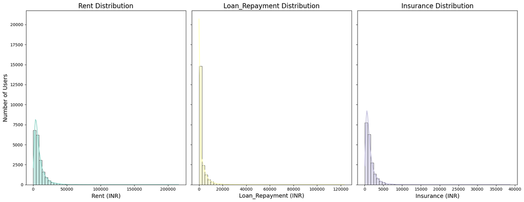

```python
fixed_expenses = ['Rent', 'Loan_Repayment', 'Insurance']
num_fixed = len(fixed_expenses)

fixed_palette = sns.color_palette("Set3", num_fixed)

fig, axes = plt.subplots(1, num_fixed, figsize=(18, 7), sharey=True)

for ax, expense, color in zip(axes, fixed_expenses, fixed_palette):
    sns.histplot(df[expense], bins=50, kde=True, color=color, ax=ax)
    ax.set_title(f'{expense} Distribution', fontsize=16)
    ax.set_xlabel(f'{expense} (INR)', fontsize=14)
    ax.set_ylabel('Number of Users', fontsize=14)

plt.tight_layout()
plt.show()
```

### Observations:

- **Rent Distribution**:
  - The majority of users pay a relatively low rent, with a sharp peak at lower rent values (likely below 20,000 INR).
  - The distribution is right-skewed, with a small number of users paying higher rents, extending up to 200,000 INR.
  - This could suggest that a significant portion of users live in less expensive regions or that housing affordability varies widely, possibly due to differences between urban and rural areas.
- **Loan Repayment Distribution**:
  - A prominent spike at or near zero indicates that a substantial proportion of users have no loan repayment obligations.
  - For those with loan repayments, the amounts are relatively low, with a rapid decline in the number of users as repayment amounts increase.
  - The overall distribution is highly right-skewed, showing that few users have high monthly loan repayments (up to 120,000 INR).
- **Insurance Distribution**:
  - Insurance premiums are generally low, with the majority of users paying minimal amounts (likely below 5,000 INR).
  - Similar to the other distributions, this data is also right-skewed, indicating that while most users pay small amounts for insurance, a few pay significantly higher premiums, extending up to 40,000 INR.
  - This suggests that a large proportion of users may have basic or minimal insurance coverage, with fewer opting for comprehensive or higher-value plans.

#### 2. Variable Expenses

Variable expenses include Groceries, Transport, Eating Out, Entertainment, Utilities, Healthcare, Education, and Miscellaneous.

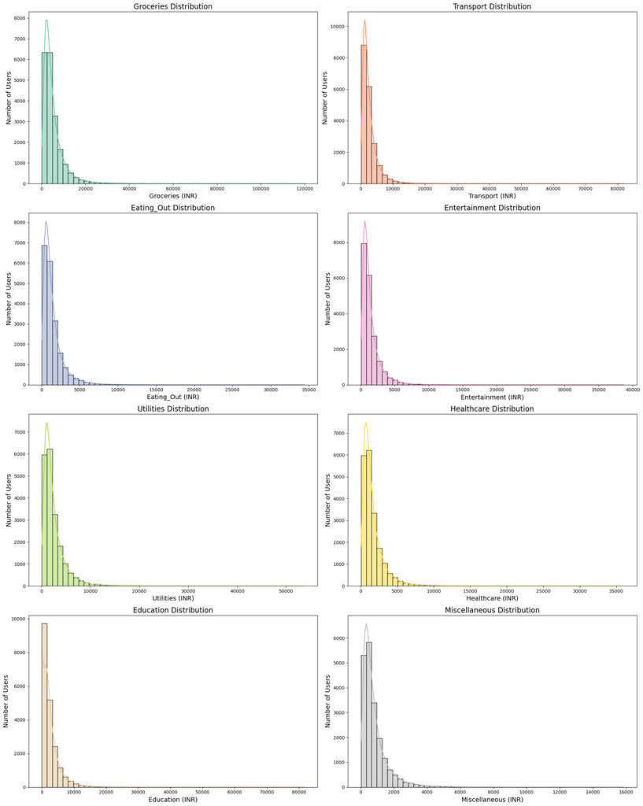

```python
variable_expenses = [
    'Groceries', 'Transport', 'Eating_Out', 'Entertainment',
    'Utilities', 'Healthcare', 'Education', 'Miscellaneous'
]
num_variable = len(variable_expenses)

variable_palette = sns.color_palette("Set2", num_variable)

fig, axes = plt.subplots(4, 2, figsize=(20, 25))
axes = axes.flatten()

for ax, expense, color in zip(axes, variable_expenses, variable_palette):
    sns.histplot(df[expense], bins=50, kde=True, color=color, ax=ax)
    ax.set_title(f'{expense} Distribution', fontsize=16)
    ax.set_xlabel(f'{expense} (INR)', fontsize=14)
    ax.set_ylabel('Number of Users', fontsize=14)

plt.tight_layout()
plt.show()
```

### Observations:

- **Groceries**: Most users spend less than 20,000 INR on groceries, with a few outliers spending significantly more. This indicates that the majority of users maintain moderate grocery expenses.
- **Transport**: The majority of users have transport expenses below 10,000 INR, with a sharp decline beyond this point, suggesting limited high transport expenditures among users.
- **Eating Out**: Most users spend below 5,000 INR on eating out, with a few spending more, indicating that dining out is not a significant expense for most.
- **Entertainment**: Entertainment expenses are generally below 5,000 INR, with the majority of users spending minimal amounts in this category, reflecting lower discretionary spending.
- **Utilities**: Users primarily have utility expenses under 10,000 INR, with a few outliers, suggesting stable and predictable utility costs for most.
- **Healthcare**: Healthcare expenses are generally low, with most users spending less than 5,000 INR, indicating limited spending on medical needs among the majority.
- **Education**: Education-related expenses are primarily below 10,000 INR, indicating that high educational costs are rare among users.
- **Miscellaneous**: Most users have miscellaneous expenses below 2,000 INR, with a few higher expenditures, indicating that additional unclassified expenses are typically small.

Each of these expense categories shows a right-skewed distribution, with the majority of users having relatively low expenditures and a smaller number spending significantly more. This suggests that while most users manage their expenses conservatively, there are outliers with higher spending in each category.

### Savings Analysis

#### 1. Desired Savings vs Income

Analyzing how desired savings correlate with income levels.

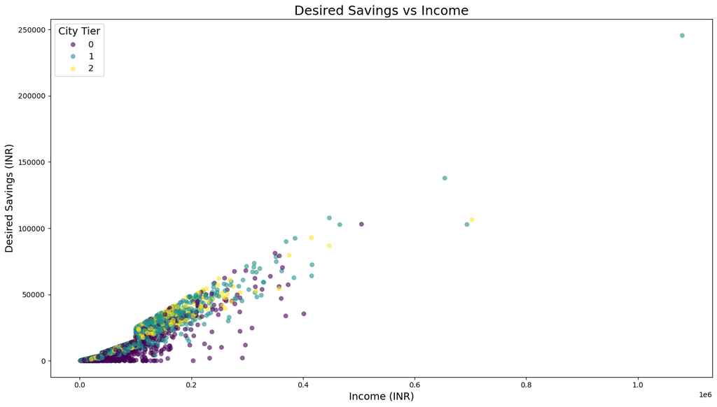

```python
plt.figure(figsize=(14, 8))
sns.scatterplot(
    data=df,
    x='Income',
    y='Desired_Savings',
    hue='City_Tier',
    palette='viridis',
    alpha=0.6,
    edgecolor=None
)
plt.title('Desired Savings vs Income', fontsize=18)
plt.xlabel('Income (INR)', fontsize=14)
plt.ylabel('Desired Savings (INR)', fontsize=14)
plt.legend(title='City Tier', fontsize=12, title_fontsize=14)
plt.tight_layout()
plt.show()
```

### Observations:

- There is a positive correlation between income and desired savings, with higher incomes leading to higher savings goals.
- Users across all city tiers follow similar savings trends, but higher-income users show more variability in their savings.
- Most users are concentrated at lower income levels, with a few outliers having significantly higher incomes and desired savings.

#### 2. Potential Savings Across Categories

Understanding how much users can potentially save in each expense category.

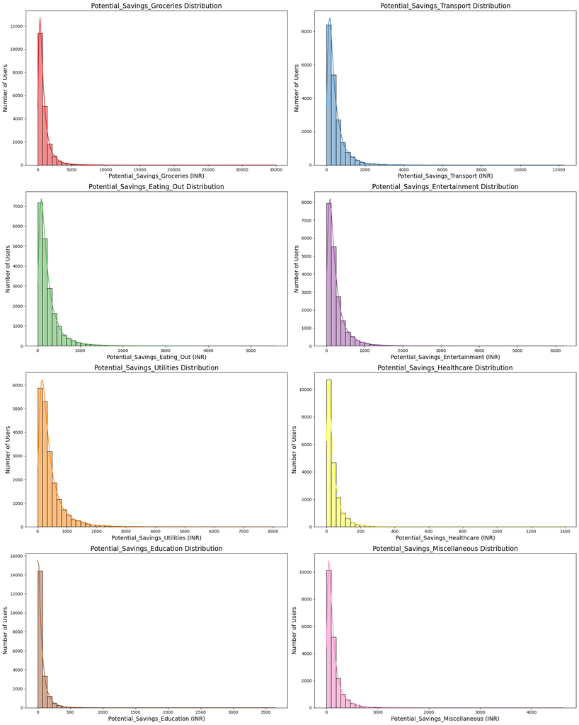

```python
potential_savings_columns = [col for col in df.columns if col.startswith('Potential_Savings')]

num_potential = len(potential_savings_columns)
palette_potential = sns.color_palette("Set1", num_potential)

fig, axes = plt.subplots(4, 2, figsize=(20, 25))
axes = axes.flatten()

for ax, column, color in zip(axes, potential_savings_columns, palette_potential):
    sns.histplot(df[column], bins=50, kde=True, color=color, ax=ax)
    ax.set_title(f'{column} Distribution', fontsize=16)
    ax.set_xlabel(f'{column} (INR)', fontsize=14)
    ax.set_ylabel('Number of Users', fontsize=14)

plt.tight_layout()
plt.show()
```

### Observations:

- **Potential Savings Distribution**: Across all expense categories, potential savings are highly skewed towards lower values, indicating that most users have limited savings potential in each category.
- **Groceries and Transport**: These categories show relatively higher potential savings compared to others, suggesting room for users to optimize spending in these areas.
- **Healthcare and Education**: Potential savings are minimal, reflecting the essential nature of these expenses, where users have less flexibility to cut costs.

### Correlation Analysis

Analyzing correlations between different financial aspects.

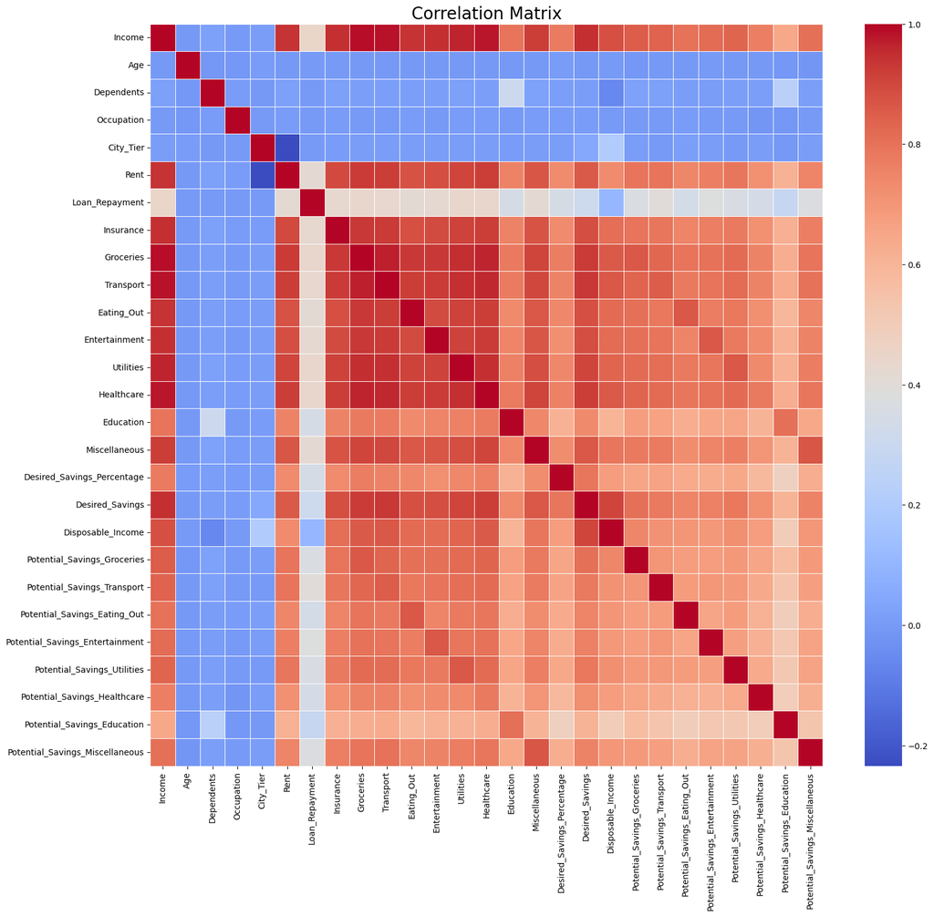

```python
numeric_df = df.select_dtypes(include=[np.number])

correlation_matrix = numeric_df.corr()

plt.figure(figsize=(18, 16))
sns.heatmap(correlation_matrix, annot=False, cmap='coolwarm', linewidths=0.5)
plt.title('Correlation Matrix', fontsize=20)
plt.show()
```

### MODEL

The following code is written to prepare the dataset so as to train a regression model to predict a person’s income based on their age, dependents, spending patterns (rent, groceries, healthcare, etc.), and categorical details like occupation and city tier — without using any features that would directly reveal the income.

```python
# Drop target and leakage columns
leakage_cols = ['Income', 'Desired_Savings', 'Disposable_Income'] + \
               [col for col in df.columns if col.startswith('Potential_Savings_')]

X = df.drop(columns=leakage_cols)
y = df['Income']

# Handle categorical variables (if not done already)
X = pd.get_dummies(X, drop_first=True)

# Split data: 80% train, 20% test
X_train, X_test, y_train, y_test = train_test_split(
    X, y, test_size=0.2, random_state=42
)

print("Training set shape:", X_train.shape)
print("Testing set shape:", X_test.shape)
```

```
Training set shape: (16000, 16)
Testing set shape: (4000, 16)
```

```python
# Basic architecture example in Keras
model = Sequential([
    Dense(64, activation='relu', input_shape=(X_train.shape[1],)),
    Dense(32, activation='relu'),
    Dense(1)  # Output layer for regression
])
model.compile(optimizer='adam', loss='mean_squared_error')
model.fit(X_train, y_train, epochs=100, batch_size=32, validation_split=0.2)
```

```
400/400 ━━━━━━━━━━━━━━━━━━━━ 3s 3ms/step - loss: 827038720.0000 - val_loss: 18759602.0000
400/400 ━━━━━━━━━━━━━━━━━━━━ 1s 2ms/step - loss: 15755330.0000 - val_loss: 12280856.0000
400/400 ━━━━━━━━━━━━━━━━━━━━ 1s 2ms/step - loss: 12220342.0000 - val_loss: 14209585.0000
400/400 ━━━━━━━━━━━━━━━━━━━━ 1s 2ms/step - loss: 13005768.0000 - val_loss: 11015941.0000
400/400 ━━━━━━━━━━━━━━━━━━━━ 1s 2ms/step - loss: 11551525.0000 - val_loss: 10087413.0000
400/400 ━━━━━━━━━━━━━━━━━━━━ 1s 2ms/step - loss: 9795587.0000 - val_loss: 9531169.0000
400/400 ━━━━━━━━━━━━━━━━━━━━ 1s 2ms/step - loss: 10892719.0000 - val_loss: 9663580.0000
400/400 ━━━━━━━━━━━━━━━━━━━━ 1s 2ms/step - loss: 11083889.0000 - val_loss: 10292575.0000
400/400 ━━━━━━━━━━━━━━━━━━━━ 1s 2ms/step - loss: 10178866.0000 - val_loss: 8887091.0000
400/400 ━━━━━━━━━━━━━━━━━━━━ 1s 2ms/step - loss: 10071924.0000 - val_loss: 9409807.0000
400/400 ━━━━━━━━━━━━━━━━━━━━ 1s 2ms/step - loss: 10400669.0000 - val_loss: 8916404.0000
400/400 ━━━━━━━━━━━━━━━━━━━━ 1s 2ms/step - loss: 11777877.0000 - val_loss: 8394945.0000
400/400 ━━━━━━━━━━━━━━━━━━━━ 1s 3ms/step - loss: 9885307.0000 - val_loss: 9577307.0000
400/400 ━━━━━━━━━━━━━━━━━━━━ 1s 2ms/step - loss: 10306809.0000 - val_loss: 11529548.0000
400/400 ━━━━━━━━━━━━━━━━━━━━ 1s 2ms/step - loss: 9734438.0000 - val_loss: 8508326.0000
400/400 ━━━━━━━━━━━━━━━━━━━━ 1s 2ms/step - loss: 9245658.0000 - val_loss: 8442904.0000
400/400 ━━━━━━━━━━━━━━━━━━━━ 1s 2ms/step - loss: 8857223.0000 - val_loss: 7587039.5000
400/400 ━━━━━━━━━━━━━━━━━━━━ 1s 2ms/step - loss: 8712387.0000 - val_loss: 11923117.0000
400/400 ━━━━━━━━━━━━━━━━━━━━ 1s 2ms/step - loss: 9606027.0000 - val_loss: 10375674.0000
400/400 ━━━━━━━━━━━━━━━━━━━━ 1s 2ms/step - loss: 8440605.0000 - val_loss: 7940784.5000
400/400 ━━━━━━━━━━━━━━━━━━━━ 1s 2ms/step - loss: 8843249.0000 - val_loss: 7305122.0000
400/400 ━━━━━━━━━━━━━━━━━━━━ 1s 2ms/step - loss: 8291954.0000 - val_loss: 7861088.5000
400/400 ━━━━━━━━━━━━━━━━━━━━ 1s 2ms/step - loss: 8562103.0000 - val_loss: 7130211.0000
400/400 ━━━━━━━━━━━━━━━━━━━━ 1s 2ms/step - loss: 8032102.5000 - val_loss: 7847166.5000
400/400 ━━━━━━━━━━━━━━━━━━━━ 1s 2ms/step - loss: 8284518.5000 - val_loss: 7211447.0000
400/400 ━━━━━━━━━━━━━━━━━━━━ 1s 2ms/step - loss: 8558352.0000 - val_loss: 7644301.5000
400/400 ━━━━━━━━━━━━━━━━━━━━ 1s 2ms/step - loss: 8329249.5000 - val_loss: 6710542.5000
400/400 ━━━━━━━━━━━━━━━━━━━━ 1s 2ms/step - loss: 7091603.0000 - val_loss: 6712055.5000
400/400 ━━━━━━━━━━━━━━━━━━━━ 1s 2ms/step - loss: 7082339.0000 - val_loss: 5825315.0000
400/400 ━━━━━━━━━━━━━━━━━━━━ 1s 2ms/step - loss: 7112308.0000 - val_loss: 6352855.0000
400/400 ━━━━━━━━━━━━━━━━━━━━ 1s 2ms/step - loss: 7455394.5000 - val_loss: 7186653.0000
400/400 ━━━━━━━━━━━━━━━━━━━━ 1s 2ms/step - loss: 6590338.5000 - val_loss: 5401408.0000
400/400 ━━━━━━━━━━━━━━━━━━━━ 1s 2ms/step - loss: 6481160.0000 - val_loss: 5010552.5000
400/400 ━━━━━━━━━━━━━━━━━━━━ 1s 2ms/step - loss: 6729386.5000 - val_loss: 5444295.0000
400/400 ━━━━━━━━━━━━━━━━━━━━ 1s 2ms/step - loss: 6536731.0000 - val_loss: 4733209.5000
400/400 ━━━━━━━━━━━━━━━━━━━━ 1s 2ms/step - loss: 5968431.0000 - val_loss: 4544226.5000
400/400 ━━━━━━━━━━━━━━━━━━━━ 1s 2ms/step - loss: 5789643.0000 - val_loss: 4627905.5000
400/400 ━━━━━━━━━━━━━━━━━━━━ 1s 2ms/step - loss: 5396998.5000 - val_loss: 4371063.5000
400/400 ━━━━━━━━━━━━━━━━━━━━ 1s 2ms/step - loss: 5193629.0000 - val_loss: 4875579.5000
400/400 ━━━━━━━━━━━━━━━━━━━━ 1s 2ms/step - loss: 5572034.5000 - val_loss: 4089654.5000
```

[output cut: 45 more lines]

```
400/400 ━━━━━━━━━━━━━━━━━━━━ 1s 2ms/step - loss: 4749522.0000 - val_loss: 3276563.2500
400/400 ━━━━━━━━━━━━━━━━━━━━ 1s 2ms/step - loss: 3588673.5000 - val_loss: 4399883.0000
400/400 ━━━━━━━━━━━━━━━━━━━━ 1s 2ms/step - loss: 4731359.5000 - val_loss: 3557430.7500
400/400 ━━━━━━━━━━━━━━━━━━━━ 1s 2ms/step - loss: 4161584.0000 - val_loss: 3965615.0000
400/400 ━━━━━━━━━━━━━━━━━━━━ 1s 2ms/step - loss: 4882314.0000 - val_loss: 3413479.2500
400/400 ━━━━━━━━━━━━━━━━━━━━ 1s 2ms/step - loss: 4490862.5000 - val_loss: 4653604.0000
400/400 ━━━━━━━━━━━━━━━━━━━━ 1s 2ms/step - loss: 4422483.0000 - val_loss: 3375016.0000
400/400 ━━━━━━━━━━━━━━━━━━━━ 1s 2ms/step - loss: 5323550.5000 - val_loss: 4144141.5000
400/400 ━━━━━━━━━━━━━━━━━━━━ 1s 2ms/step - loss: 4141722.2500 - val_loss: 3284763.7500
400/400 ━━━━━━━━━━━━━━━━━━━━ 1s 2ms/step - loss: 4366565.0000 - val_loss: 3525432.0000
400/400 ━━━━━━━━━━━━━━━━━━━━ 1s 2ms/step - loss: 4090941.0000 - val_loss: 3772088.2500
400/400 ━━━━━━━━━━━━━━━━━━━━ 1s 2ms/step - loss: 3908858.2500 - val_loss: 4423566.0000
400/400 ━━━━━━━━━━━━━━━━━━━━ 1s 2ms/step - loss: 4115745.0000 - val_loss: 3687363.5000
400/400 ━━━━━━━━━━━━━━━━━━━━ 1s 3ms/step - loss: 4434126.5000 - val_loss: 5093612.0000
400/400 ━━━━━━━━━━━━━━━━━━━━ 1s 3ms/step - loss: 4007515.2500 - val_loss: 3412786.0000
```

```
<keras.src.callbacks.history.History at 0x26620ec3560>
```

```python
# Predict on test set
nn_y_pred = model.predict(X_test)

# Compute metrics
nn_mse = mean_squared_error(y_test, nn_y_pred)
nn_mae = mean_absolute_error(y_test, nn_y_pred)
nn_r2 = r2_score(y_test, nn_y_pred)

print(f'Neural Network Mean Squared Error: {nn_mse}')
print(f'Neural Network Mean Absolute Error: {nn_mae}')
print(f'Neural Network R-squared: {nn_r2}')
```

```
125/125 ━━━━━━━━━━━━━━━━━━━━ 0s 1ms/step
Neural Network Mean Squared Error: 3833206.910974666
Neural Network Mean Absolute Error: 790.0579518563894
Neural Network R-squared: 0.9978806291165092
```

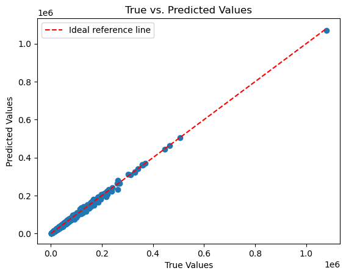

```python
# Scatter plot of actual vs predicted values for Neural Network
plt.scatter(y_test, nn_y_pred)
plt.plot([min(y_test), max(y_test)], [min(y_test), max(y_test)], 'r--', label= 'Ideal reference line')
plt.xlabel('True Values')
plt.ylabel('Predicted Values')
plt.title('True vs. Predicted Values')
plt.legend()
plt.show()
```

#### Key points:

If the model is perfect, all the points will lie on the ideal refrence diagonal line which is plotted as a dashed red line.

*Points above the line:* Model over-predicts.

*Points below the line:* Model under-predicts.

The closer the points are to the diagonal, the better the model’s predictions match the true values.

### Random forest regressor

```python
rf_model = RandomForestRegressor(n_estimators=100, random_state=42)
rf_model.fit(X_train, y_train)
rf_y_pred = rf_model.predict(X_test)

rf_mse = mean_squared_error(y_test, rf_y_pred)
rf_mae = mean_absolute_error(y_test, rf_y_pred)
rf_r2 = r2_score(y_test, rf_y_pred)

print(f"Random Forest MSE: {rf_mse}")
print(f"Random Forest MAE: {rf_mae}")
print(f"Random Forest R²: {rf_r2}")
```

```
Random Forest MSE: 53652104.33061681
Random Forest MAE: 1088.7114040279664
Random Forest R²: 0.9703358805310596
```

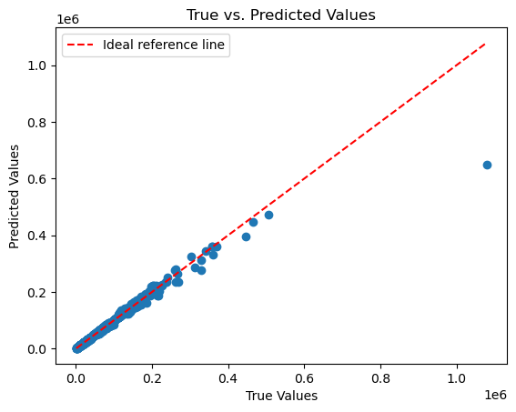

```python
# Scatter plot of actual vs predicted values for Random Forest
plt.scatter(y_test, rf_y_pred)
plt.plot([min(y_test), max(y_test)], [min(y_test), max(y_test)], 'r--', label= 'Ideal reference line')
plt.xlabel('True Values')
plt.ylabel('Predicted Values')
plt.title('True vs. Predicted Values')
plt.legend()
plt.show()
```

### XGBoost model

```python
# Create XGBoost model
xgb_model = xgb.XGBRegressor(objective='reg:squarederror', random_state=42)

# Train the model
xgb_model.fit(X_train, y_train)

# Predict on the test set
xgb_y_pred = xgb_model.predict(X_test)

# Compute metrics for XGBoost
xgb_mse = mean_squared_error(y_test, xgb_y_pred)
xgb_mae = mean_absolute_error(y_test, xgb_y_pred)
xgb_r2 = r2_score(y_test, xgb_y_pred)

print(f"XGBoost MSE: {xgb_mse}")
print(f"XGBoost MAE: {xgb_mae}")
print(f"XGBoost R²: {xgb_r2}")
```

```
XGBoost MSE: 165775310.85695145
XGBoost MAE: 1485.5133702652413
XGBoost R²: 0.9083432292616506
```

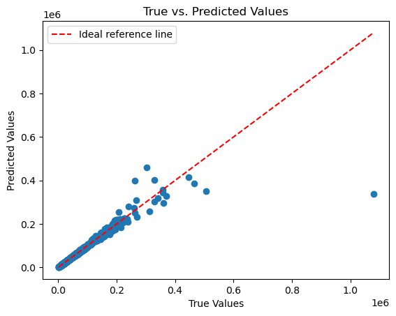

```python
# Scatter plot of actual vs predicted values for XGBoost
plt.scatter(y_test, xgb_y_pred)
plt.plot([min(y_test), max(y_test)], [min(y_test), max(y_test)], 'r--', label= 'Ideal reference line')
plt.xlabel('True Values')
plt.ylabel('Predicted Values')
plt.title('True vs. Predicted Values')
plt.legend()
plt.show()
```

### Performance comparision of the models

```
Model Comparison:
Neural Network MSE: 3833206.910974666
Random Forest MSE: 53652104.33061681
XGBoost MSE: 165775310.85695145

Neural Network MAE: 790.0579518563894
Random Forest MAE: 1088.7114040279664
XGBoost MAE: 1485.5133702652413

Neural Network R²: 0.9978806291165092
Random Forest R²: 0.9703358805310596
XGBoost R²: 0.9083432292616506
```

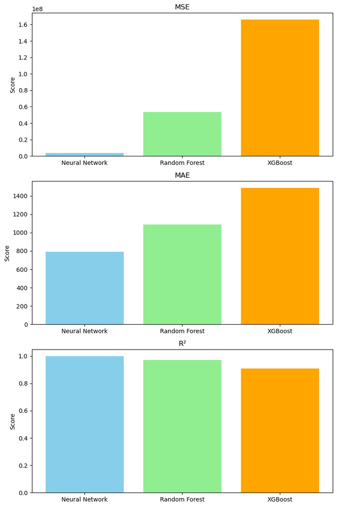

```python
# Print the comparison of the models
print("Model Comparison:")
print(f"Neural Network MSE: {nn_mse}")
print(f"Random Forest MSE: {rf_mse}")
print(f"XGBoost MSE: {xgb_mse}")
print()
print(f"Neural Network MAE: {nn_mae}")
print(f"Random Forest MAE: {rf_mae}")
print(f"XGBoost MAE: {xgb_mae}")
print()
print(f"Neural Network R²: {nn_r2}")
print(f"Random Forest R²: {rf_r2}")
print(f"XGBoost R²: {xgb_r2}")

# Plot the results
metrics = ['MSE', 'MAE', 'R²']
nn_scores = [nn_mse, nn_mae, nn_r2]
rf_scores = [rf_mse, rf_mae, rf_r2]
xgb_scores = [xgb_mse, xgb_mae, xgb_r2]

models = ['Neural Network', 'Random Forest', 'XGBoost']
scores = [nn_scores, rf_scores, xgb_scores]

fig, axs = plt.subplots(3,1, figsize=(8, 12))

for i, metric in enumerate(metrics):
    axs[i].bar(models, [nn_scores[i], rf_scores[i], xgb_scores[i]], color=['skyblue', 'lightgreen', 'orange'])
    axs[i].set_title(metric)
    axs[i].set_ylabel('Score')

plt.tight_layout()
plt.show()
```

#### Observation:

Based on these results, the Neural Network model is the most accurate and reliable for this particular regression task, achieving substantially lower prediction errors (low MSE and MAE)0 and explaining nearly all variance (high R2 score) in the target variable compared to Random Forest and XGBoost.